# Tutorial 2 — Model Validation

Hurricane Wind Hazard Model for the Caribbean

Published

April 15, 2026

**NotePrerequisites**

This tutorial assumes you have completed Tutorial 1, which introduces the baseline hazard workflow and the `out` object that we validate here.

This tutorial mirrors the production validation pipeline in `inst/extcode/02-model-validation.R`. We run a stationary baseline simulation, exercise the three-tier validation suite, and inspect the diagnostics that result.

## 1 What This Tutorial Covers

By the end, you will be able to:

- create a baseline model output suitable for validation;
- configure and run the validation suite with `make_validation_cfg()` and `run_validation_suite()`;
- interpret each of the three validation tiers (hindcast return levels, rate sanity, wind-field spot-checks);
- read the saved plots and tables produced when `save_plots = TRUE` and `save_tables = TRUE`.

## 2 Overview

The validation framework has three tiers, run in one suite call:

1. **Tier 1 — Hindcast.** Hold out the last `HOLDOUT_YEARS` of the historical record, refit on the training period, simulate `N_SIM` synthetic years, and compare simulated vs. observed return levels at the requested return periods. A well-calibrated model places simulated return levels inside the observed confidence interval at most sites.
2. **Tier 2 — Rate check.** Compare calibrated annual storm-class rates (TS, HUR) against published HURDAT2/IBTrACS climatologies, after adjusting for the methodological mismatch between site-exceedance counting and basin-track counting.
3. **Tier 3 — Wind field.** Spot-check the Holland wind-profile model against historical station observations for documented storm passages and report site-level bias.

```r
library(ipdcstorm)
library(dplyr)
library(ggplot2)
```

## 3 Configuration

Settings here match the production script `inst/extcode/02-model-validation.R`. Lower `N_SIM` to render the tutorial faster while you are exploring; use 2,000 for any defensible result.

```r
SEED             <- 42L
N_SIM            <- 2000L
HIST_START_YEAR  <- 1970L
SEARCH_RADIUS_KM <- 800

# Years held out from the end of the historical record for the hindcast.
HOLDOUT_YEARS <- 10L

# Return periods (yr) to evaluate. Keep these within ~ record length / 3
# so that empirical observed quantiles remain stable.
RETURN_PERIODS <- c(5, 10, 25, 50, 100)

# Confidence level used for the observed return-level CI in Tier 1.
CONF_LEVEL <- 0.95

# Where saved plots/tables go.
SAVE_OUTPUTS <- TRUE
OUT_DIR      <- "output/validation"
```

```r
targets <- tibble::tribble(
  ~name,         ~lat,      ~lon,
  "St_Martin",   18.0708,  -63.0501,
  "Saba",        17.6350,  -63.2300,
  "Statia",      17.4890,  -62.9740
)
```

## 4 Create a Model Output to Validate

The validation suite operates on a standard `run_hazard_model()` output. We use the packaged 1970+ IBTrACS subset so the tutorial renders end-to-end without external data.

```r
DATA_PATH <- system.file("extdata", "ibtracs_1970.csv", package = "ipdcstorm")

hazard_cfg <- make_hazard_cfg(
  data_path             = DATA_PATH,
  search_radius_km      = SEARCH_RADIUS_KM,
  historical_start_year = HIST_START_YEAR,
  simulation_years      = N_SIM,
  climate               = make_climate_cfg(scenario = "stationary")
)
```

```r
out_base <- run_hazard_model(
  cfg     = hazard_cfg,
  targets = targets,
  seed    = SEED,
  verbose = FALSE
)
```

## 5 Validation Configuration

`make_validation_cfg()` packages the validation parameters and the output behaviour into one object. Setting `full_output = TRUE` returns the internal hindcast object and the file paths of saved artifacts in addition to the slim summary tibbles.

```r
val_cfg <- make_validation_cfg(
  holdout_years  = HOLDOUT_YEARS,
  n_sim          = N_SIM,
  return_periods = RETURN_PERIODS,
  conf_level     = CONF_LEVEL,
  seed           = SEED,
  out_dir        = OUT_DIR,
  save_plots     = SAVE_OUTPUTS,
  save_tables    = SAVE_OUTPUTS,
  full_output    = TRUE
)

val_cfg
```

```
#> Validation configuration
#>   Holdout       : 10 years
#>   Simulation    : 2,000 synthetic years
#>   Return periods: 5, 10, 25, 50, 100 yr
#>   Conf. level   : 95%
#>   Seed          : 42
#>   Output dir    : output/validation
#>   Save plots    : yes
#>   Save tables   : yes
#>   GEV xi bounds : [-0.30, 0.40]
```

| Parameter | Description |
| --- | --- |
| `holdout_years` | Number of years withheld from the end of the historical record for the train/test split. |
| `n_sim` | Number of synthetic years simulated for the hindcast. `NULL` inherits from `out_base`. |
| `return_periods` | Return periods (yr) at which observed and simulated return levels are compared. |
| `conf_level` | Confidence level for the observed return-level CI; controls the strictness of the Tier 1 pass test. |
| `seed` | RNG seed; should match the seed used for the baseline run. |
| `out_dir` | Destination directory for saved plots and tables. |
| `save_plots` / `save_tables` | Toggles for writing PNG figures and CSV tables. |
| `full_output` | When `TRUE`, also returns `hindcast`, `climate_response`, and `artifacts` (file paths). |

## 6 Run the Validation Suite

A single call runs all three tiers and returns a structured list. The function prints a console summary as it works.

```r
val_out <- run_validation_suite(
  out = out_base,
  cfg = val_cfg
)
```

```r
val_out$summary
```

```
#> # A tibble: 3 × 4
#>   location  storm_class delta_top1_p50 delta_overall_p99
#>   <chr>     <chr>                <dbl>             <dbl>
#> 1 Saba      TS                    5.77              16.8
#> 2 St_Martin TS                  -30.8              -13.5
#> 3 Statia    TS                    2.59              13.0
```

**NoteWhat’s in `val_out`**

Default output contains `summary`, `comparison` (Tier 1), `rate_check` (Tier 2), `wind_field` (Tier 3), and `plots` (list of ggplot objects). With `full_output = TRUE`, you also get `hindcast`, `climate_response`, and `artifacts` (paths to saved PNGs and CSVs). The on-disk bundle lives in `OUT_DIR`.

## 7 Tier 1 — Hindcast Return Levels

Tier 1 asks whether the model, refit on the training record, reproduces return levels implied by the full observed record. The pass test is whether `sim_rl` falls inside the observed `[obs_ci_lo, obs_ci_hi]` interval.

```r
hc_tbl <- val_out$comparison

hc_tbl |>
  mutate(across(where(is.numeric), ~ round(.x, 1))) |>
  arrange(location, return_period)
```

```
#> # A tibble: 15 × 15
#>    location  return_period obs_full_rl obs_test_rl sim_rl sim_median sim_ci_lo
#>    <chr>             <dbl>       <dbl>       <dbl>  <dbl>      <dbl>     <dbl>
#>  1 Saba                  5        44.4        46.6   49.2       49.2      47.8
#>  2 Saba                 10        53          60.6   58.2       58.3      56.6
#>  3 Saba                 25        60          63.6   66.3       66.3      64.4
#>  4 Saba                 50        63.8        63.6   70.9       71        68.6
#>  5 Saba                100        66.8        63.6   74.7       74.8      72.1
#>  6 St_Martin             5        49          46.8   47.4       47.4      45.6
#>  7 St_Martin            10        59.3       130.    57.6       57.7      54.8
#>  8 St_Martin            25        68.3       149.    66.4       66.4      62.3
#>  9 St_Martin            50        73.2       149.    71.4       71.4      66.4
#> 10 St_Martin           100        77.1       149.    75.4       75.4      69.7
#> 11 Statia                5        44.7        44.7   50.3       50.2      48.9
#> 12 Statia               10        52.2        59.1   60.6       60.5      58.5
#> 13 Statia               25        58.8        62.3   71.6       71.6      68.2
#> 14 Statia               50        62.6        62.3   79.1       78.9      74.6
#> 15 Statia              100        65.8        62.3   86         85.8      80.4
#> # ℹ 8 more variables: sim_ci_hi <dbl>, obs_ci_lo <dbl>, obs_ci_hi <dbl>,
#> #   obs_ci_method <chr>, obs_in_ci <lgl>, model_in_obs_ci <lgl>,
#> #   obs_in_model_ci <lgl>, bias_pct <dbl>
```

```r
n_checks  <- nrow(hc_tbl)
n_in_ci   <- sum(hc_tbl$obs_in_ci, na.rm = TRUE)
pct_in_ci <- round(100 * n_in_ci / n_checks, 1)

sprintf("Pass rate: %d / %d checks within %d%% CI  (%.1f%%)",
        n_in_ci, n_checks, round(CONF_LEVEL * 100), pct_in_ci)
```

```
#> [1] "Pass rate: 14 / 15 checks within 95% CI  (93.3%)"
```

| Column | Description |
| --- | --- |
| `location` | Target site. |
| `return_period` | Return period in years. |
| `obs_full_rl` | Observed return level from the full historical record (kt). |
| `sim_rl` | Simulated return level from the `N_SIM` ensemble (kt). |
| `obs_ci_lo` / `obs_ci_hi` | Bounds of the observed return-level CI at `conf_level` (kt). |
| `obs_in_ci` | `TRUE` if `sim_rl` falls within the observed CI. |
| `bias_pct` | Percentage bias `100 * (sim_rl - obs_full_rl) / obs_full_rl`; positive = overprediction. |

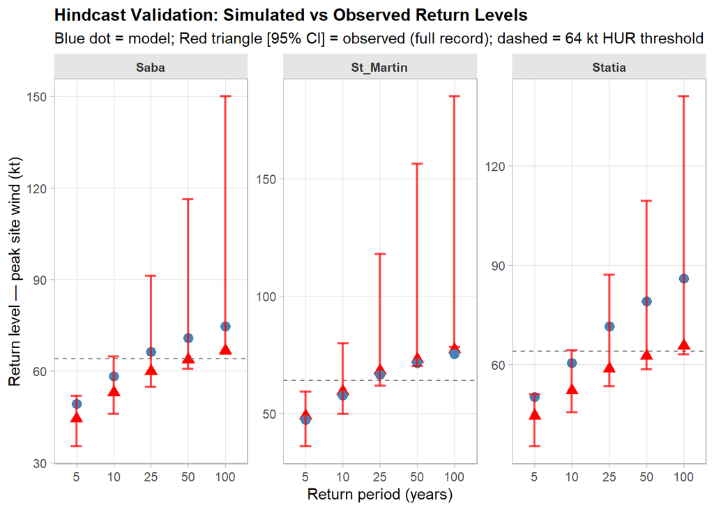

Figure 1: Hindcast validation: simulated vs observed return levels.

```r
val_out$plots$hindcast_return_levels
```

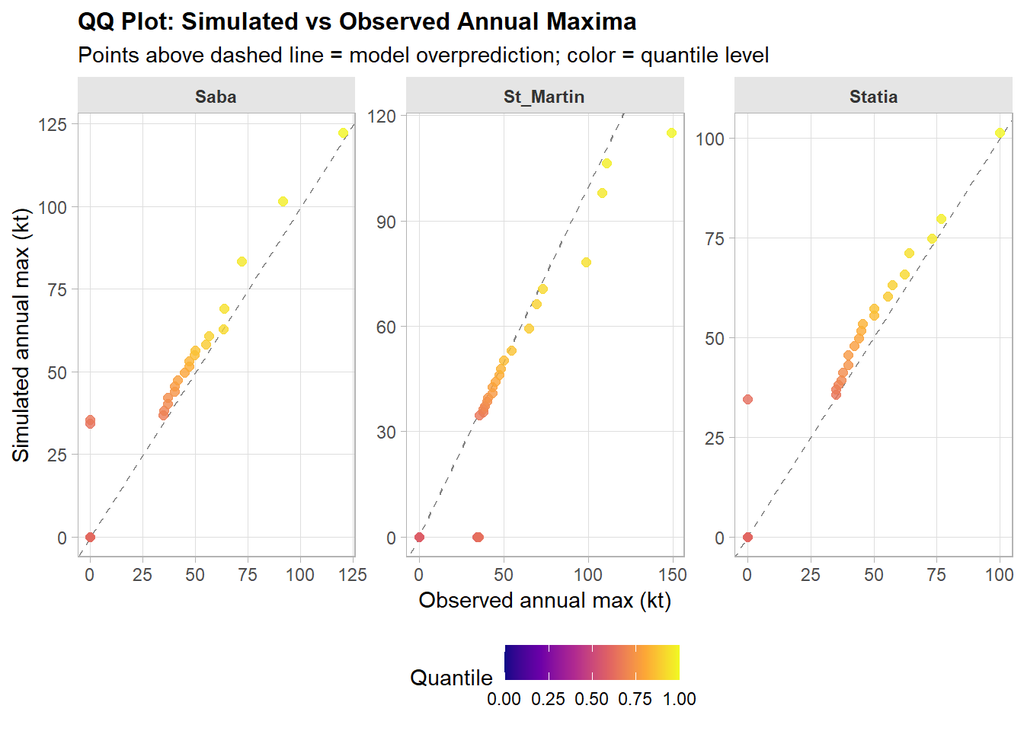

Figure 2: QQ plot of simulated vs observed annual maxima.

```r
val_out$plots$qq_annual_max
```

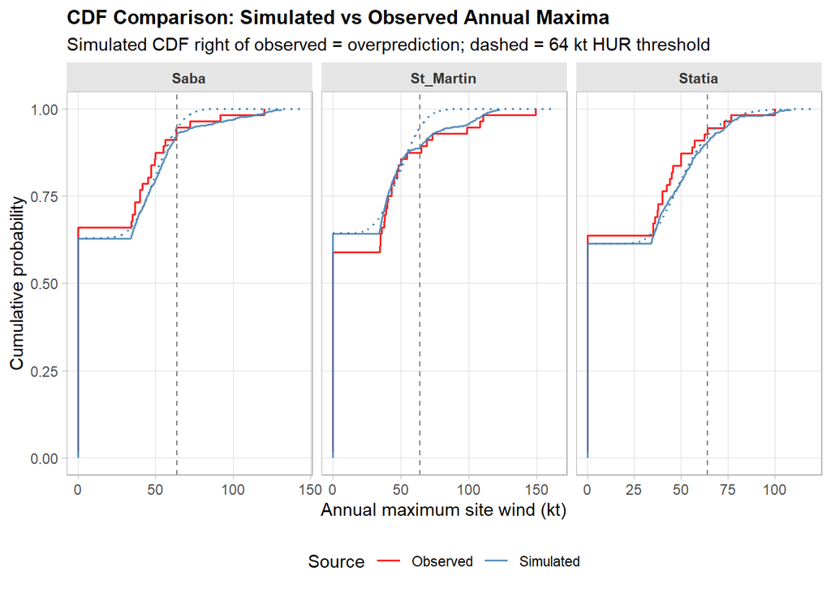

Figure 3: CDF comparison of simulated and observed annual maxima.

```r
val_out$plots$exceedance_comparison
```

**NoteWhy the CI is on the observed curve**

CIs are placed on the observed return levels, not the simulated ones. Once the synthetic sample is large, fitting uncertainty on `sim_rl` is small relative to sampling uncertainty in the short observational record.

**TipRead the QQ plot first**

The QQ plot is the fastest way to localize bias by intensity. Upper-tail points above the 1:1 line indicate the model is overshooting the tail; points below indicate underprediction.

## 8 Tier 2 — Rate Sanity Check

Tier 2 compares the model’s annual rates of TS- and HUR-class impacts against published climatology. The model counts site exceedances; references count basin-track passages within a radius. The check applies an expected-ratio adjustment before flagging.

```r
val_out$rate_check |>
  mutate(across(where(is.numeric), ~ round(.x, 3)))
```

```
#> # A tibble: 6 × 19
#>   location  storm_class lambda_model lambda_model_raw n_years_model lambda_ref
#>   <chr>     <chr>              <dbl>            <dbl>         <dbl>      <dbl>
#> 1 St_Martin TS                 0.393            0.393            56       0.8
#> 2 Saba      TS                 0.489            0.489            47       1.45
#> 3 Statia    TS                 0.5              0.5              46       1.45
#> 4 St_Martin HUR                0.125            0.125            56       0.4
#> 5 Saba      HUR                0.064            0.064            47       0.55
#> 6 Statia    HUR                0.087            0.087            46       0.55
#> # ℹ 13 more variables: lambda_target <dbl>, lambda_scale <dbl>,
#> #   lambda_adj <dbl>, scale_status <chr>, scale_clamped <lgl>, source <chr>,
#> #   gate_approx_nm <dbl>, period <chr>, expected_ratio <dbl>, raw_ratio <dbl>,
#> #   ratio <dbl>, adj_ratio <dbl>, flag <chr>
```

```r
n_flagged <- sum(val_out$rate_check$flag != "OK", na.rm = TRUE)

if (n_flagged > 0) {
  sprintf("%d rate(s) flagged — review search_radius_km or historical_start_year.", n_flagged)
} else {
  "All rates within reference bounds."
}
```

```
#> [1] "All rates within reference bounds."
```

| Column | Description |
| --- | --- |
| `lambda_model_raw` | Raw annual rate estimated by the model before adjustment. |
| `lambda_ref` | Published reference annual rate for the site/storm class. |
| `lambda_adj` | Adjusted model rate used for the comparison. |
| `expected_ratio` | Expected model/reference ratio given counting-method differences. |
| `adj_ratio` | Adjusted model-to-reference ratio (after `expected_ratio` correction). |
| `flag` | `OK`, `elevated`, `slightly_low`, `HIGH`, or `LOW`. |

**NoteFlag interpretation**

`OK` is within band. `elevated` / `slightly_low` are mild discrepancies worth noting. `HIGH` / `LOW` are stronger mismatches: investigate `search_radius_km`, `historical_start_year`, or possible regional rate departures from basin climatology.

## 9 Tier 3 — Wind-Field Spot-Checks

Tier 3 compares modelled site winds for individual historical storms against station observations. Observations are graded by quality class with class-specific bias tolerances: `A` = direct, ±15 %; `B` = converted, ±25 %; `C` = approximate, ±35 %.

```r
val_out$wind_field |>
  mutate(across(where(is.numeric), ~ round(.x, 2)))
```

```
#> # A tibble: 8 × 19
#>   location    storm_name storm_sid  year station obs_raw_kt obs_type obs_quality
#>   <chr>       <chr>      <chr>     <dbl> <chr>        <dbl> <chr>    <chr>
#> 1 St_Martin   IRMA       2017242N…  2017 Meteo_…        113 10min_s… B
#> 2 St_Martin   GONZALO    2014279N…  2014 Julian…         60 1min_su… A
#> 3 Saba        IRMA       2017242N…  2017 NHC_es…         80 1min_su… C
#> 4 St_Martin   MARIA      2017255N…  2017 Julian…         40 1min_su… A
#> 5 Puerto_Rico HUGO       1989248N…  1989 Roosev…        104 1min_su… A
#> 6 Miami       ANDREW     1992216N…  1992 NHC_Mi…        141 1min_su… A
#> 7 St_Martin   LENNY      1999317N…  1999 Julian…         55 1min_su… A
#> 8 St_Martin   LUIS       1995241N…  1995 Julian…        110 1min_su… A
#> # ℹ 11 more variables: obs_1min_equiv_kt <dbl>, model_V_site_kt <dbl>,
#> #   model_wind_max_kt <dbl>, min_dist_km <dbl>, storm_found <lgl>,
#> #   bias_kt <dbl>, bias_pct <dbl>, bias_threshold_pct <dbl>, bias_ok <lgl>,
#> #   source <chr>, notes <chr>
```

| Column | Description |
| --- | --- |
| `storm_name` | Historical storm used for the comparison. |
| `location` | Target site. |
| `obs_1min_equiv_kt` | Observed wind, converted to a 1-minute sustained equivalent (kt). |
| `model_V_site_kt` | Modelled peak site wind (kt). |
| `bias_kt` | Model − observed (kt). |
| `bias_pct` | Percentage bias. |
| `obs_quality` | Observation quality class (`A`, `B`, `C`). |
| `bias_ok` | `TRUE` if `\|bias_pct\|` falls within the class tolerance. |

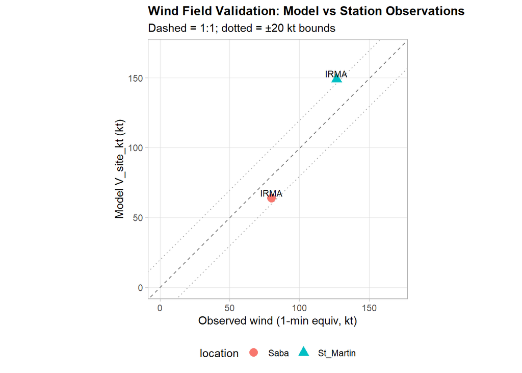

Figure 4: Wind-field validation: modelled vs observed site winds.

```r
val_out$plots$wind_field_scatter
```

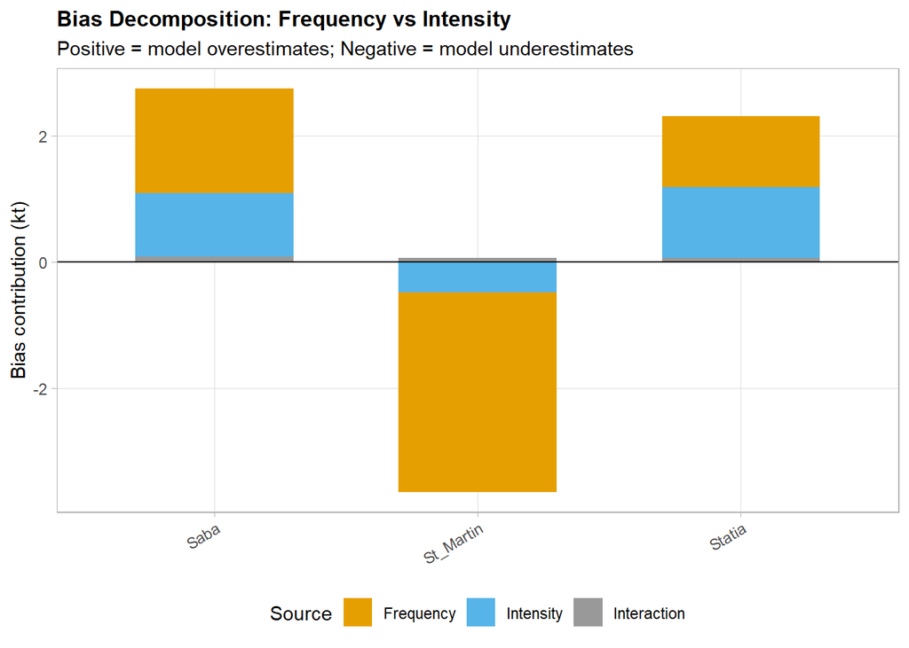

Figure 5: Bias decomposition: frequency vs intensity contributions.

```r
val_out$plots$bias_decomposition
```

**NoteThis tier is the hardest to pass cleanly**

Station observations are point measurements affected by terrain, exposure, and instrumentation. Biases of order ±20 % are expected; persistent same-sign bias across many storms suggests the radius–wind relationship needs regional tuning.

## 10 Interpreting Results and Next Steps

Read the tiers together rather than in isolation:

- A **Tier 1** miss (sim outside CI) without a Tier 2 or Tier 3 problem usually points to tail-shape issues — check the GEV fit, holdout length, and whether the most intense observed events fall in the holdout.
- A **Tier 2** flag normally points to a counting/scope mismatch — re-examine `search_radius_km`, `historical_start_year`, and the per-class reference ratios.
- A **Tier 3** persistent bias points to the wind-profile parameterisation (Holland B, RMW estimate, asymmetry) rather than to the stochastic generator.

Use the bias decomposition plot to separate frequency-driven bias (too many or too few impactful events) from intensity-driven bias (events of the right count but wrong magnitude).

**TipOne-step shortcut**

`validate_hazard_model()` runs the hazard model and the validation suite in one call. Keep the two-step pattern shown here while you are inspecting outputs; switch to the wrapper for repeat runs.

**TipTargeted reruns**

The package also exposes the individual tier functions: `validate_rates()` and `validate_wind_field()`. Use these to iterate on a single tier without re-running the others.

## 11 Saved Outputs

With `save_plots = TRUE` and `save_tables = TRUE`, the suite writes a small report bundle to `OUT_DIR`.

```r
val_out$artifacts
```

```
#> $plots
#> $plots$hindcast_return_levels
#> [1] "output/validation/hindcast_return_levels.png"
#>
#> $plots$wind_field_scatter
#> [1] "output/validation/wind_field_scatter.png"
#>
#> $plots$bias_decomposition
#> [1] "output/validation/bias_decomposition.png"
#>
#> $plots$qq_annual_max
#> [1] "output/validation/qq_annual_max.png"
#>
#> $plots$exceedance_comparison
#> [1] "output/validation/exceedance_comparison.png"
#>
#>
#> $tables
#> $tables$hindcast_csv
#> [1] "output/validation/hindcast_return_levels.csv"
#>
#> $tables$rate_check_csv
#> [1] "output/validation/rate_check.csv"
#>
#> $tables$wind_field_csv
#> [1] "output/validation/wind_field.csv"
#>
#> $tables$summary_csv
#> [1] "output/validation/validation_summary.csv"
```

| File | Description |
| --- | --- |
| `hindcast_return_levels.png` | Return-level comparison with confidence intervals. |
| `qq_annual_max.png` | QQ plot of annual maxima. |
| `exceedance_comparison.png` | CDF comparison of observed and simulated annual maxima. |
| `wind_field_scatter.png` | Modelled vs observed site winds. |
| `bias_decomposition.png` | Frequency vs intensity bias contributions. |
| `hindcast_return_levels.csv` | Tier 1 comparison table. |
| `rate_check.csv` | Tier 2 rate-check table. |
| `wind_field.csv` | Tier 3 wind-field bias table. |
| `validation_summary.csv` | Compact per-location validation summary across tiers. |

Once you can read the three tiers fluently, the same workflow scales to your own sites and longer model runs. A model that fails Tier 1 at more than one site should be recalibrated (revisit `search_radius_km` or `historical_start_year`) before drawing conclusions from any climate-change projection built on top of it.